# InVivoStat Single Measure Parametric Analysis

## Diagnostic plots

### Residuals vs. predicted plot

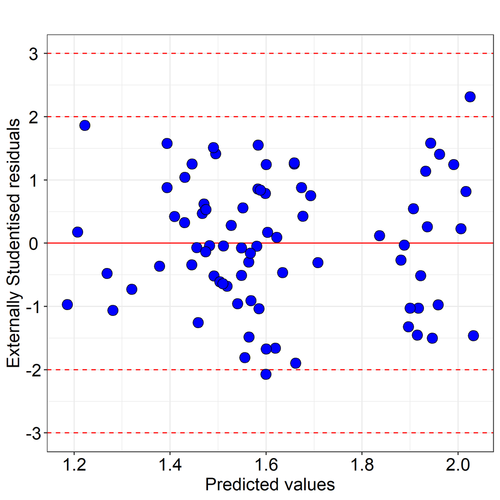

Tip: On this plot look to see if the spread of the points increases as the predicted values increase. If so the response may need transforming.

Tip: Any observation with a residual less than -3 or greater than 3 (SD) should be investigated as a possible outlier.

### Normal probability plot

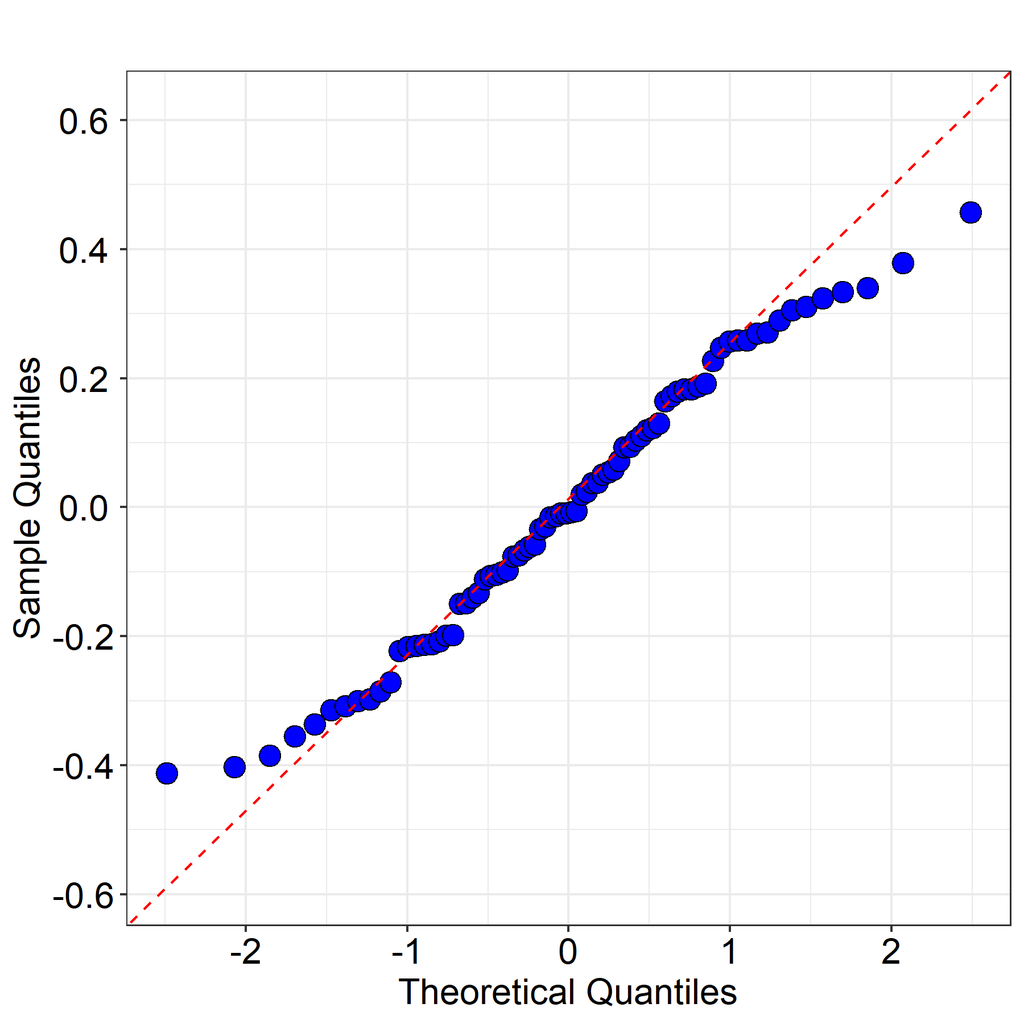

Tip: Check that the points lie along the dotted line. If not then the data may be non-normally distributed.

## Table of the least square (predicted) means with 95% confidence intervals

| Mean ID | Treat2 | Mean | Lower 95% CI | Upper 95% CI |
| --- | --- | --- | --- | --- |
| 1 | F | 1.615 | 1.535 | 1.696 |
| 2 | M | 1.612 | 1.533 | 1.691 |

## Plot of the least square (predicted) means with 95% confidence intervals

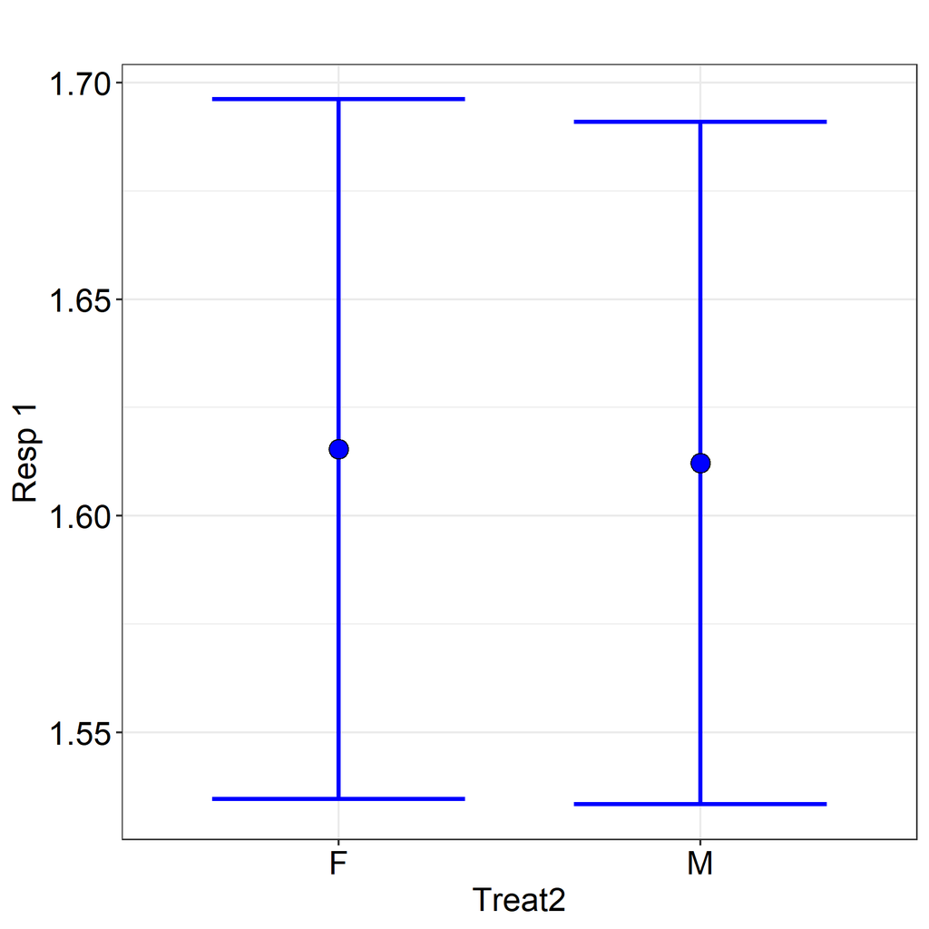

## All pairwise comparisons using Holm's procedure

| Comparison | Difference | Lower 95% CI | Upper 95% CI | Std error | p-value |
| --- | --- | --- | --- | --- | --- |
| F - M | 0.003 | -0.110 | 0.116 | 0.056 | 0.9545 |

Conclusion: At the 5% level, the pairwise comparison is not statistically significant.

Warning: It is not advisable to draw statistical inferences about a factor/interaction in the presence of a significant higher-order interaction involving that factor/interaction.

Note: The confidence intervals quoted are not adjusted for multiplicity.

## All to one comparisons using Holm's procedure

| Comparison | Difference | Lower 95% CI | Upper 95% CI | Std error | p-value |
| --- | --- | --- | --- | --- | --- |
| F - M | 0.003 | -0.110 | 0.116 | 0.056 | 0.9545 |

## Plot of the comparisons between the predicted means with 95% confidence intervals

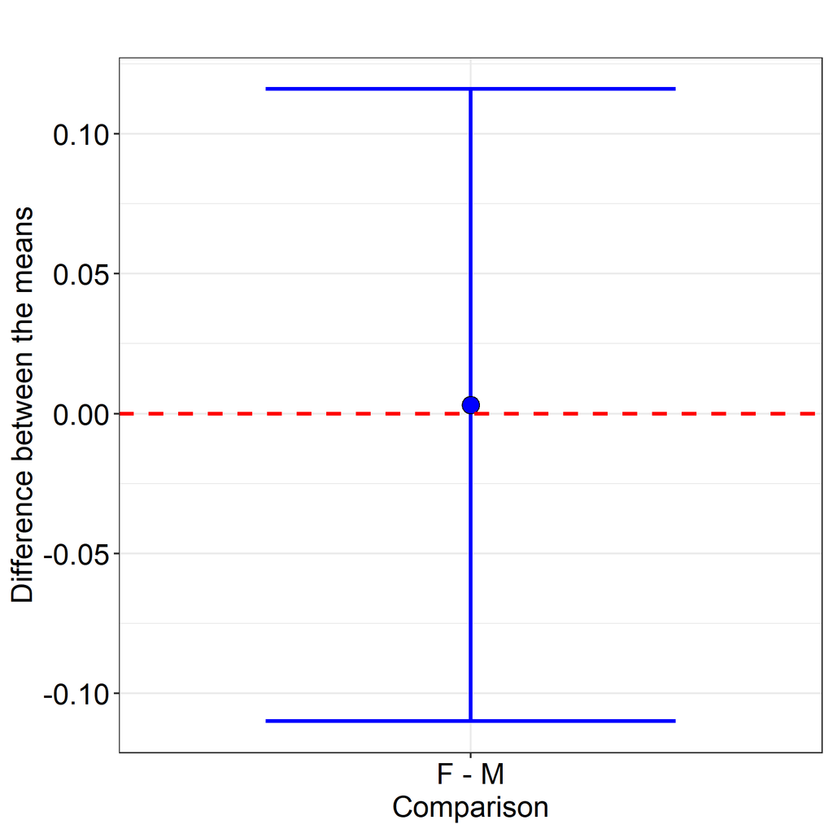

Conclusion: At the 5% level, the pairwise comparison is not statistically significant.

Warning: It is not advisable to draw statistical inferences about a factor/interaction in the presence of a significant higher-order interaction involving that factor/interaction. In the above table certain higher order interactions are assumed to be not significant, see log for more details.

Note: The confidence intervals quoted are not adjusted for multiplicity.

## Analysis description

The data were analysed using a 3-way ANOVA approach, with Treat1, Treat2 and Treat3 as the treatment factors and Blo ck1 and Blo ck2 as the blocking factors. This was followed by comparisons of the predicted means of the Treat2 factor back to the control group mean using Holm's procedure, Holm (1979). This was followed by all pairwise comparisons between the predicted means of the Treat2 factor using Holm's procedure, Holm (1979).

For more information on the theoretical approaches that are implemented within this module, see Bate and Clark (2014).

## References

When referring to InVivoStat, please cite 'InVivoStat, version 5.2.0'.

Bate, S.T. and Clark, R.A. (2014). The Design and Statistical Analysis of Animal Experiments. Cambridge University Press.

Armitage, P., Matthews, J.N.S. and Berry, G. (2001). Statistical Methods in Medical Research. 4th edition; John Wiley & Sons. New York.

Holm, S. (1979). A simple sequentially rejective multiple test procedure. Scandinavian Journal of Statistics, 6, 65-70.